# Week 02

Data visualization

### Statistician(s) of the Week

[W.E.B. DuBois](https://hardin47.github.io/CURV/scholars/dubois.html)

Check out his [book](https://www.amazon.com/W-Boiss-Data-Portraits-Visualizing/dp/1616897066)! I have a copy in my office.

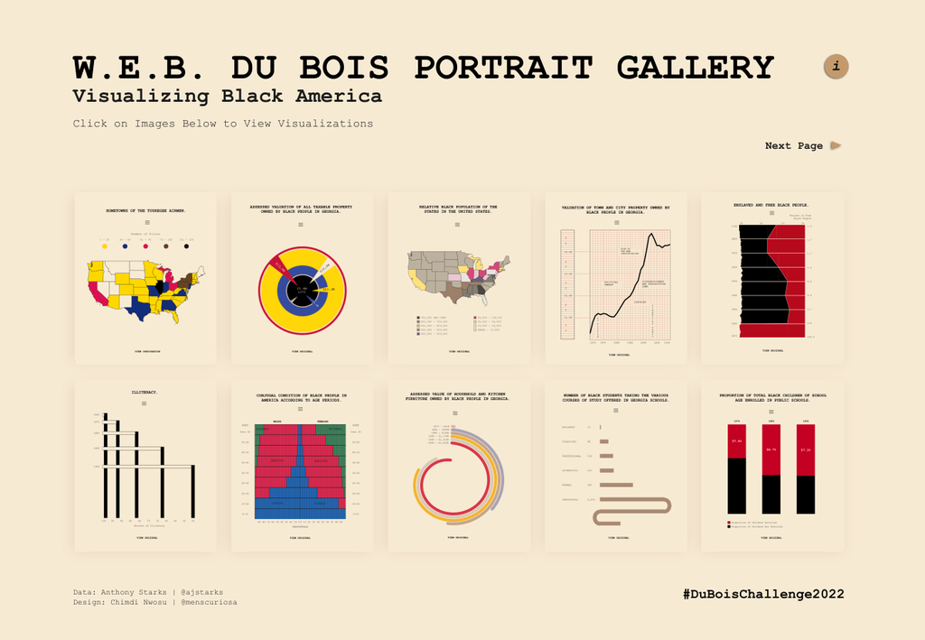

[Florence Nightingale](https://hardin47.github.io/CURV/scholars/nightingale.html)

[figure not shown]

### Announcements

- Annotations due Thursday
- Lab 01 due Thursday
- First quiz on Thursday. To prepare,
  - Week 01 & 02 lecture slides
  - Lab 01
  - AE in class today

### A few notes / tips

- Add `color = "white"` to your `geom_histogram()` layers

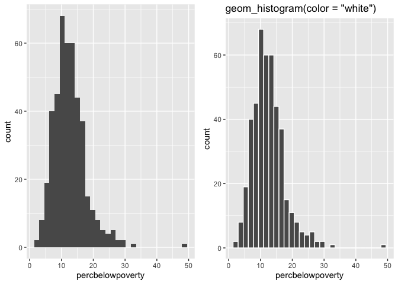

- Check out different theme options in `ggplot`. Default is `theme_gray()`. I typically use `theme_minimal()` to de-clutter some of the background.

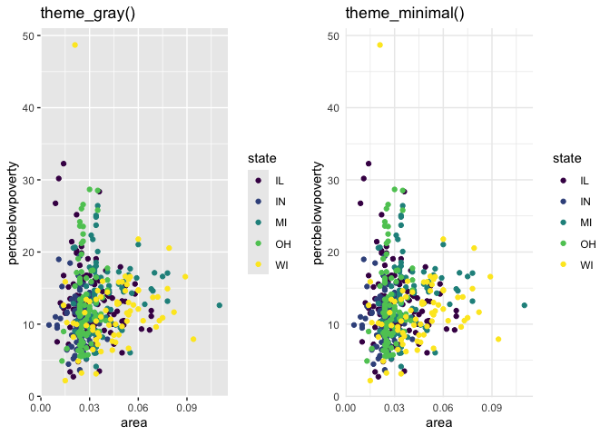

- The [`ggthemes` package](https://github.com/jrnold/ggthemes) has many additional themes to choose from

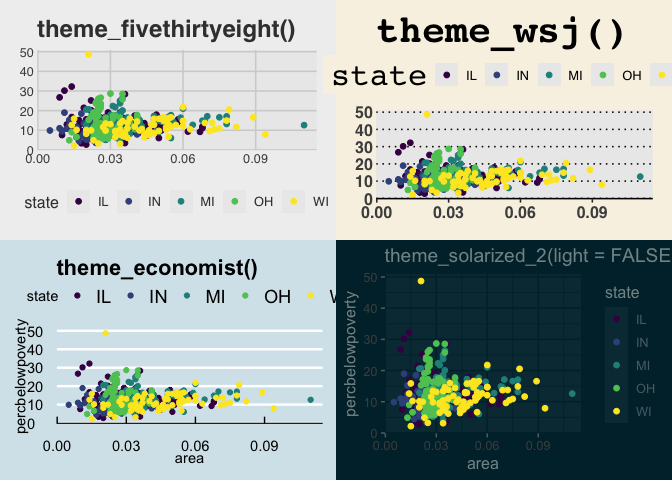

- This blogpost [“Themes to spice up visualizations with ggplot2”](https://towardsdatascience.com/themes-to-spice-up-visualizations-with-ggplot2-3e275038dafa) suggests several more packages with many additional themes to play with
- Make sure to use colorblind friendly pallets! `scale_color_viridis_d` (and its variations) is my default, `scale_color_colorblind()` is another common option, from the `ggthemes` package

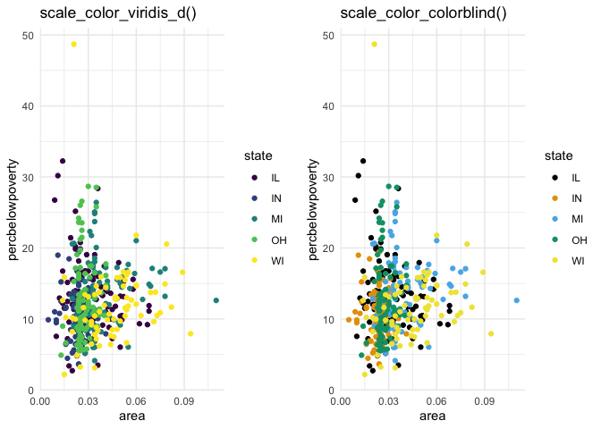

- Save the fiddling with beautification until the end - this can be an endless time suck if you’re not careful :)
- Keep in mind that you’re not just practicing your technical coding skills, but you’re also developing your investigative skills as a data scientist - **be curious about the data** and **dig further** into it when your visualizations reveal certain patterns or unusual observations.

### Application Exercise

- The remainder of class will be spent on AE-02.
- You can access it from GitHub.
- It is due at the end of class today.
- To turn it in, you should upload your .html file to Brightspace.